# Summer School Prep

This notebook will do teh prep-work necessary ot try to be ready for 2025 model based neuroscience summer school

First we load the package

```r
#install.packages("EMC2")
library(EMC2)
```

The constraints of this package is as follows: - Data needs to be in a data.frame format - Column containing participant identifiers - Column containing responses (titled R) - Column containing response time in seconds (rt)

I then downloaded the LVABvE, DDMavE and DDMae into my environment for data (from “osf.io/7euya/” website)

First we need to load the data with the example dataset in the package and examine it

```r
dat <- forstmann
head(dat)
```

|  | subjects | E | S | R | rt |
| --- | --- | --- | --- | --- | --- |
| 1115 | as1t | accuracy | right | right | 0.4319 |
| 1116 | as1t | speed | right | right | 0.5015 |
| 1117 | as1t | speed | left | left | 0.3104 |
| 1118 | as1t | accuracy | right | right | 0.4809 |
| 1119 | as1t | accuracy | left | left | 0.3415 |
| 1120 | as1t | neutral | left | left | 0.3465 |

```r
NA
```

In the data where correctness is not added automatically we need to create it

[figure not shown]

```r
plot_density(dat, factors = c("S", "E"), layout = c(2,3))
```

To get a visual impression of the data we have loaded

```r
plot_density(dat, factors = c("S", "E"), layout = c(2,3))
```

[output not shown]

To make it into a one subject analysis we extract the first subject from the dataset

```r
dat_single <- dat[dat$subjects == levels(dat$subjects)[1],] # Selecting the first subject
dat_single$subjects <- factor(dat_single$subjects)
```

We then sepcify the formula for the model

```r
formula <- list(v~0+S, a~E, t0~1, s~1, Z~1, sv~1)

# Constants are specified at the rate of which sampling takes place

# We then fit the formula to the data - that is wrong
# We instead specify the model design
design_DDMaE <- design(data = dat_single, model=DDM, constants = c(s=log(1)),
                       formula = formula)
```

```
Parameter(s) st0, SZ not specified in formula and assumed constant.
```

```
 Sampled Parameters:
[1] "v_Sleft"     "v_Sright"    "a"           "a_Eneutral"  "a_Eaccuracy"
[6] "t0"          "Z"           "sv"

 Design Matrices:
$v
     S v_Sleft v_Sright
  left       1        0
 right       0        1

$a
        E a a_Eneutral a_Eaccuracy
    speed 1          0           0
  neutral 1          1           0
 accuracy 1          0           1

$t0
 t0
  1

$s
 s
 1

$Z
 Z
 1

$sv
 sv
  1

$st0
 st0
   1

$SZ
 SZ
  1
```

```r
?design
```

```r
# Set prior mean
prior_mean <- c(v_Sleft=-2, v_Sright=2, a=log(1), a_Eneutral=log(1.5),
                a_Eaccuracy=log(2), t0 = log(.2), Z=qnorm(.5), sv=log(.5))

# Set prior standard deviation
prior_sd <- c(v_Sleft=1,v_Sright=1,a=.3,a_Eneutral=.3,a_Eaccuracy=.3,
           t0=.4,Z=1,sv=.4,SZ=1)

# Construct prior
prior_DDMaE <- prior(design_DDMaE,pmean = prior_mean, psd = prior_sd,
                     type = "single")
```

We then set the the priors which the model uses

```r
DDMaE <- make_emc(dat_single,design_DDMaE, prior=prior_DDMaE)
```

```
Processing data set 1
Likelihood speedup factor: 3.5 (232 unique trials)
```

We then display the priors for visual inspection

```r
plot(prior_DDMaE, layout = c(2,4))
```

[output not shown]

When using different models there is a compare function which can be used to look at them in the package - Always a good idea to display beforehand tho

What we need to do to get the trials sorted correctly is to parse them into correct and faulty trials (something about that in one of the lectures but not sure the degree of which it applies)

To make it into an object (I think) with the make_emc function

```r
DDMaE <- make_emc(dat_single,design_DDMaE, prior=prior_DDMaE)
```

We then fit the model object to our data - which might take a jiffy

```r
DDMaE <- fit(DDMaE)
```

After having run this there are some tests which could be useful to do Including:

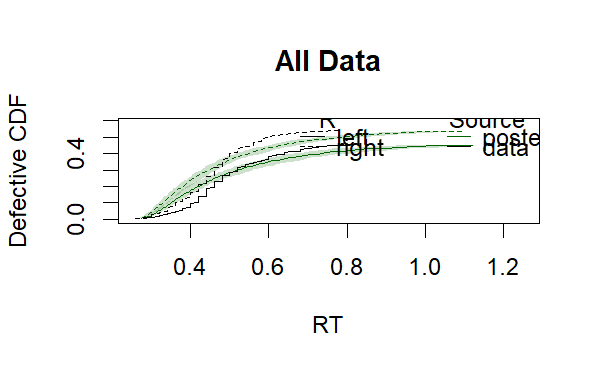

```r
?predict
pp_DDMaE <- predict(DDMaE)
plot_cdf(DDMaE, pp_DDMaE)
```

Summary:

```r
summary(DDMaE)
```

[output not shown]

And comparison of priors and posteriors

```r
?plot_pars
plot_pars(DDMaE)
```

[output not shown]

After having done this we then want to see how the model fits the data

In which we first use the predict function to use the model to predict our data and plot the different cdfs for comparison

```r
?predict
pp_DDMaE <- predict(DDMaE)
plot_cdf(DDMaE, pp_DDMaE)
```

[output not shown]